# Network Analysis of Sex Addiction and DASS21

BH

2024-04-12

```r
library(bootnet)
library(haven)
library(networktools)
library(NetworkComparisonTest)
library(qgraph)
library(tidyverse)
library(naniar)
library(mice)
library(VIM)
library(psych)
library(formatR)
library(haven)
library(bnlearn)
library(bnviewer)
library(igraph)
library(dplyr)
library(GPArotation)
```

#Set working directory and load dataset as Data <- read_sav(“provide file location”)

```r
## How many participants by category?

Data %>%
    group_by(Category) %>%
    count()
```

```
## # A tibble: 3 × 2
## # Groups:   Category [3]
##   Category     n
##      <int> <int>
## 1        1   211
## 2        2   529
## 3        3   194
```

#Percentage of missing data in the dataset

```r
D1 <- Data %>%
    select(11, 113:118, 192:212)

## This calculates % of missing data
totalcells <- prod(dim(D1))
missingcells <- sum(is.na(D1))
perc <- (missingcells * 100)/(totalcells)
perc
```

```
## [1] 0.152952
```

```r
mcar_test(D1)
```

```
## # A tibble: 1 × 4
##   statistic    df   p.value missing.patterns
##       <dbl> <dbl>     <dbl>            <int>
## 1      769.   619 0.0000360               24
```

#Variables with highest number of missing values

```r
D1 %>%
    select(!1) %>%
    summarise(across(everything(), ~sum(is.na(.)))) %>%
    pivot_longer(cols = everything(), names_to = "names", values_to = "values") %>%
    arrange(desc(values)) %>%
    mutate(perc = (values)/934) %>%
    slice_head(n = 20)
```

```
## # A tibble: 20 × 3
##    names values    perc
##    <chr>  <int>   <dbl>
##  1 DS3        4 0.00428
##  2 DS6        4 0.00428
##  3 DS12       4 0.00428
##  4 DS7        3 0.00321
##  5 DS21       3 0.00321
##  6 SX2        2 0.00214
##  7 SX4        2 0.00214
##  8 DS8        2 0.00214
##  9 DS13       2 0.00214
## 10 DS16       2 0.00214
## 11 DS19       2 0.00214
## 12 SX3        1 0.00107
## 13 SX5        1 0.00107
## 14 DS1        1 0.00107
## 15 DS2        1 0.00107
## 16 DS4        1 0.00107
## 17 DS5        1 0.00107
## 18 DS9        1 0.00107
## 19 DS11       1 0.00107
## 20 DS14       1 0.00107
```

```r
## Data imputation with Predictive Mean Matching (PMM) and 50 iterations D2 <-
## sapply(D1, haven::zap_labels) ## this line converts doubles into integers
## imputed_data <- mice(D2, m=5, maxit = 50, method = 'pmm', seed = 500)
## summary(imputed_data) completeData <- as_tibble(complete(imputed_data,2))

# write_sav(completeData, 'Complete_data.sav') write.csv(completeData,
# 'complete.csv')
```

#Reliability and define categories for analysis

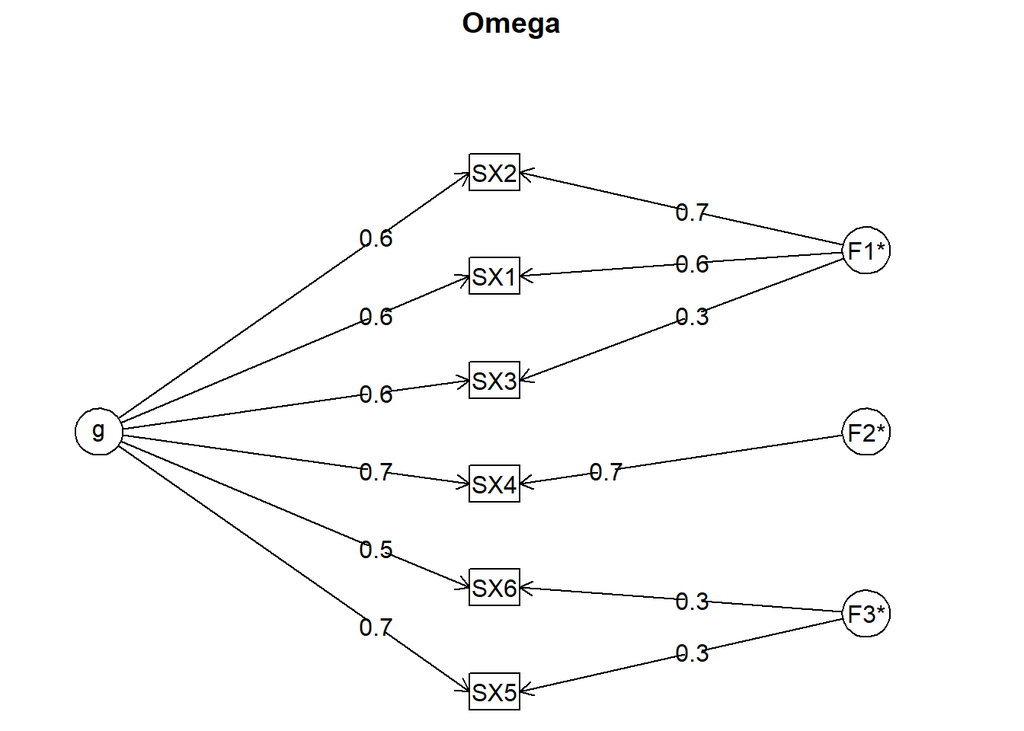

```
## Omega
## Call: omegah(m = m, nfactors = nfactors, fm = fm, key = key, flip = flip,
##     digits = digits, title = title, sl = sl, labels = labels,
##     plot = plot, n.obs = n.obs, rotate = rotate, Phi = Phi, option = option,
##     covar = covar)
## Alpha:                 0.83
## G.6:                   0.83
## Omega Hierarchical:    0.69
## Omega H asymptotic:    0.77
## Omega Total            0.89
##
## Schmid Leiman Factor loadings greater than  0.2
##        g   F1*   F2*   F3*   h2   u2   p2
## SX1 0.56  0.62             0.69 0.31 0.45
## SX2 0.61  0.70             0.86 0.14 0.43
## SX3 0.60  0.30             0.48 0.52 0.75
## SX4 0.73        0.68       1.00 0.00 0.54
## SX5 0.67              0.26 0.54 0.46 0.82
## SX6 0.48              0.31 0.33 0.67 0.70
##
## With Sums of squares  of:
##    g  F1*  F2*  F3*
## 2.26 0.98 0.47 0.20
##
## general/max  2.3   max/min =   5.02
## mean percent general =  0.62    with sd =  0.16 and cv of  0.27
## Explained Common Variance of the general factor =  0.58
##
## The degrees of freedom are 0  and the fit is  0
## The number of observations was  934  with Chi Square =  0.04  with prob <  NA
## The root mean square of the residuals is  0
## The df corrected root mean square of the residuals is  NA
##
## Compare this with the adequacy of just a general factor and no group factors
## The degrees of freedom for just the general factor are 9  and the fit is  0.6
## The number of observations was  934  with Chi Square =  553.34  with prob <  2.1e-113
## The root mean square of the residuals is  0.14
## The df corrected root mean square of the residuals is  0.18
##
## RMSEA index =  0.254  and the 10 % confidence intervals are  0.237 0.273
## BIC =  491.78
##
## Measures of factor score adequacy
##                                                  g  F1*  F2*   F3*
## Correlation of scores with factors            0.85 0.82 0.82  0.45
## Multiple R square of scores with factors      0.73 0.68 0.68  0.20
## Minimum correlation of factor score estimates 0.45 0.36 0.35 -0.59
##
##  Total, General and Subset omega for each subset
##                                                  g  F1*  F2*  F3*
## Omega total for total scores and subscales    0.89 0.85 0.99 0.59
## Omega general for total scores and subscales  0.69 0.47 0.53 0.48
## Omega group for total scores and subscales    0.17 0.39 0.46 0.12
```

```r
# check dataset after imputation and reimport. Remove column 1 and edit
# headings if required
D3 <- read.csv("Complete1.csv")

view(D3)
D_sex_reliability <- D3 %>%
    select(2:7)

omega(D_sex_reliability)
```

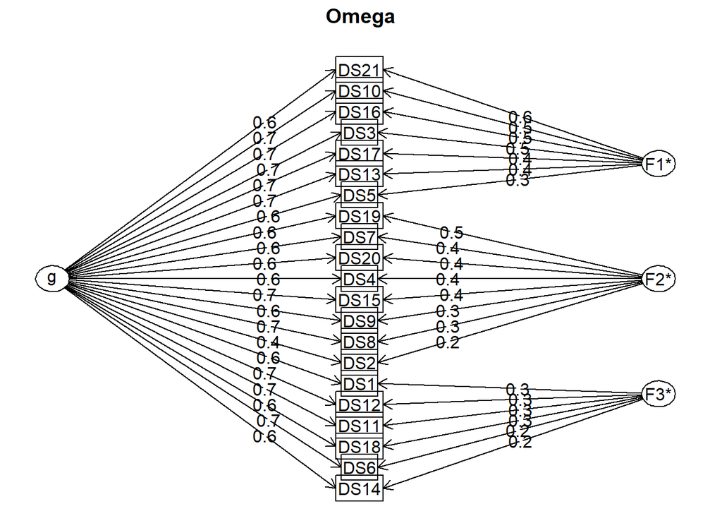

```
## Omega
## Call: omegah(m = m, nfactors = nfactors, fm = fm, key = key, flip = flip,
##     digits = digits, title = title, sl = sl, labels = labels,
##     plot = plot, n.obs = n.obs, rotate = rotate, Phi = Phi, option = option,
##     covar = covar)
## Alpha:                 0.95
## G.6:                   0.96
## Omega Hierarchical:    0.82
## Omega H asymptotic:    0.85
## Omega Total            0.96
##
## Schmid Leiman Factor loadings greater than  0.2
##         g   F1*   F2*   F3*   h2   u2   p2
## DS1  0.63              0.33 0.51 0.49 0.78
## DS2  0.42        0.24       0.23 0.77 0.74
## DS3  0.67  0.47             0.67 0.33 0.67
## DS4  0.57        0.40       0.49 0.51 0.67
## DS5  0.63  0.31             0.50 0.50 0.78
## DS6  0.66              0.23 0.51 0.49 0.84
## DS7  0.57        0.41       0.49 0.51 0.66
## DS8  0.69        0.28       0.58 0.42 0.81
## DS9  0.63        0.30       0.49 0.51 0.80
## DS10 0.66  0.54             0.74 0.26 0.60
## DS11 0.70              0.27 0.58 0.42 0.85
## DS12 0.73              0.33 0.64 0.36 0.82
## DS13 0.69  0.44             0.68 0.32 0.70
## DS14 0.61              0.21 0.44 0.56 0.86
## DS15 0.69        0.36       0.62 0.38 0.78
## DS16 0.65  0.54             0.72 0.28 0.59
## DS17 0.67  0.45             0.66 0.34 0.68
## DS18 0.62              0.26 0.46 0.54 0.84
## DS19 0.59        0.46       0.56 0.44 0.62
## DS20 0.64        0.41       0.57 0.43 0.71
## DS21 0.63  0.57             0.73 0.27 0.55
##
## With Sums of squares  of:
##    g  F1*  F2*  F3*
## 8.58 1.66 1.14 0.52
##
## general/max  5.18   max/min =   3.18
```

[output cut: 15 more lines]

```
##
## RMSEA index =  0.119  and the 10 % confidence intervals are  0.115 0.123
## BIC =  1376.69
##
## Measures of factor score adequacy
##                                                  g  F1*  F2*   F3*
## Correlation of scores with factors            0.91 0.80 0.71  0.58
## Multiple R square of scores with factors      0.83 0.64 0.50  0.33
## Minimum correlation of factor score estimates 0.66 0.27 0.00 -0.34
##
##  Total, General and Subset omega for each subset
##                                                  g  F1*  F2*  F3*
## Omega total for total scores and subscales    0.96 0.93 0.88 0.85
## Omega general for total scores and subscales  0.82 0.61 0.65 0.73
## Omega group for total scores and subscales    0.10 0.32 0.23 0.12
```

```r
D_DASS_reliability <- D3 %>%
    select(8:28)

omega(D_DASS_reliability)
```

```r
D4 <- D3 %>%
    select(!Category)

Female_hetero <- D3 %>%
    filter(Category == 1) %>%
    select(!Category)

Male_hetero <- D3 %>%
    filter(Category == 2) %>%
    select(!Category)

LGBTQ <- D3 %>%
    filter(Category == 3) %>%
    select(!Category)
```

#Estimate network

```r
network1 <- estimateNetwork(D4, default = "EBICglasso")
network1
```

```
##
## === Estimated network ===
## Number of nodes: 27
## Number of non-zero edges: 159 / 351
## Mean weight: 0.03530125
## Network stored in x$graph
##
## Default set used: EBICglasso
##
## Use plot(x) to plot estimated network
## Use bootnet(x) to bootstrap edge weights and centrality indices
##
## Relevant references:
##
##      Friedman, J. H., Hastie, T., & Tibshirani, R. (2008). Sparse inverse covariance estimation with the graphical lasso. Biostatistics, 9 (3), 432-441.
##  Foygel, R., & Drton, M. (2010). Extended Bayesian information criteria for Gaussian graphical models.
##  Friedman, J. H., Hastie, T., & Tibshirani, R. (2014). glasso: Graphical lasso estimation of gaussian graphical models. Retrieved from https://CRAN.R-project.org/package=glasso
##  Epskamp, S., Cramer, A., Waldorp, L., Schmittmann, V. D., & Borsboom, D. (2012). qgraph: Network visualizations of relationships in psychometric data. Journal of Statistical Software, 48 (1), 1-18.
##  Epskamp, S., Borsboom, D., & Fried, E. I. (2016). Estimating psychological networks and their accuracy: a tutorial paper. arXiv preprint, arXiv:1604.08462.
```

#Conduct bootstrapping to determine stability of resulting networks

```r
# b1 <- bootnet(network1, boots=1000, type='nonparametric', nCores = 8,
# statistics=c('strength', 'expectedInfluence', 'edge')) b2 <-
# bootnet(network1, boots=1000, type='case', nCores = 8, statistics =
# c('strength','expectedInfluence'))

## After bootstrapping has been performed, results can be saved

# saveRDS(b1, file = 'b1.RDS') saveRDS(b2, file = 'b2.RDS')
b1 <- readRDS("b1.RDS")
b2 <- readRDS("b2.RDS")
```

#Correlation stability coefficient and plot CS larger than 0.7 is excellent, 0.5 < CS < 0.7 is acceptable, CS < 0.5 not acceptable

```r
corStability(b2)
```

```
## === Correlation Stability Analysis ===
##
## Sampling levels tested:
##    nPerson Drop%   n
## 1      234  74.9 113
## 2      306  67.2  82
## 3      379  59.4  72
## 4      451  51.7 109
## 5      524  43.9 122
## 6      597  36.1 100
## 7      669  28.4  99
## 8      742  20.6  99
## 9      815  12.7 102
## 10     887   5.0 102
##
## Maximum drop proportions to retain correlation of 0.7 in at least 95% of the samples:
##
## expectedInfluence: 0.749 (CS-coefficient is highest level tested)
##   - For more accuracy, run bootnet(..., caseMin = 0.672, caseMax = 1)
##
## strength: 0.749 (CS-coefficient is highest level tested)
##   - For more accuracy, run bootnet(..., caseMin = 0.672, caseMax = 1)
##
## Accuracy can also be increased by increasing both 'nBoots' and 'caseN'.
```

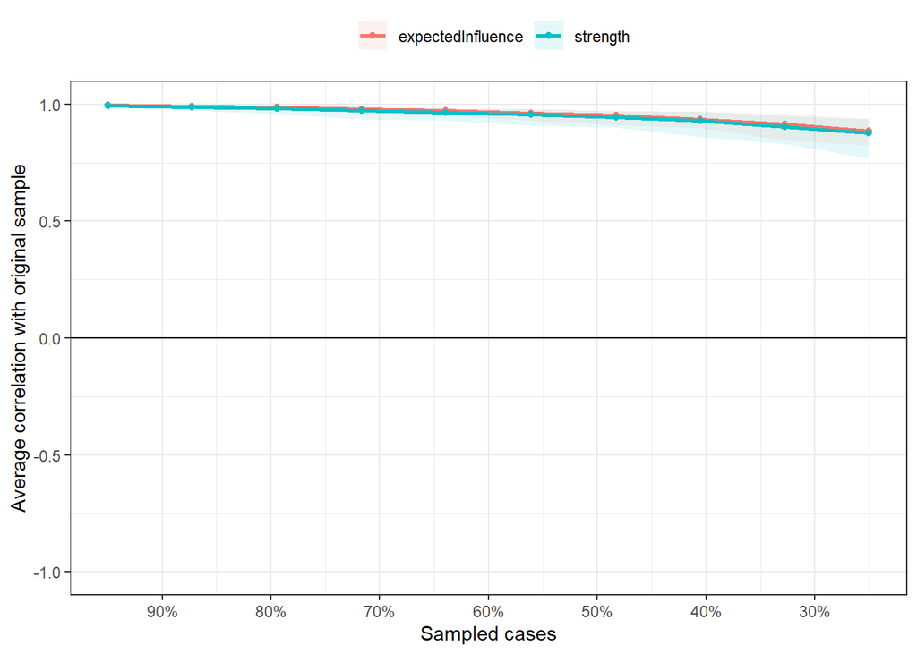

```r
plot(b2, "all")
```

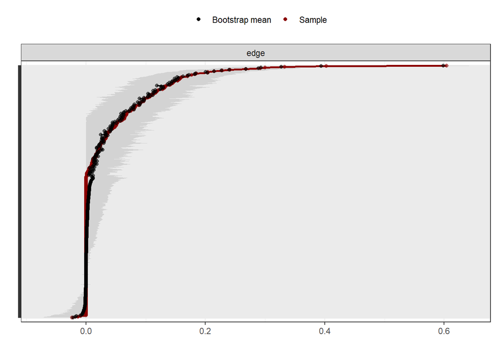

```r
# pdf('edge_stability.pdf')
plot(b1, labels = F, order = "sample")
```

#Define groups and legend for nodes

```r
groups1 <- list(BYSAS = c(1:6), Depression = c(9, 11, 16, 19, 22, 23, 27), Anxiety = c(8,
    10, 13, 15, 21, 25, 26), Stress = c(7, 12, 14, 17, 18, 20, 24))
Names <- c("Think about sex", "Increased sexual urges", "Use sex to escape", "Unsuccessfully reduce sex",
    "Troubled if prohibited from sex", "Sex has negative impact", "Hard to wind down",
    "dryness of mouth", "no positive feeling", "breathing difficulties", "no initiative",
    "over-react to situations", "experienced trembling", "using nervous energy",
    "worried I might panic", "nothing to look forward to", "found myself agitated",
    "difficult to relax", "down-hearted and blue", "intolerant to distraction", "close to panic",
    "no enthusiasm", "unworthy as person", "felt I was touchy", "aware of heartbeat",
    "scared without reason", "life is meaningless")
```

#Estimate and plot male_hetero network

```r
male_hetero_network <- as_tibble(getWmat(network_males_hetero <- estimateNetwork(Male_hetero,
    default = "EBICglasso")))

network_males_hetero
```

```
##
## === Estimated network ===
## Number of nodes: 27
## Number of non-zero edges: 170 / 351
## Mean weight: 0.03539589
## Network stored in x$graph
##
## Default set used: EBICglasso
##
## Use plot(x) to plot estimated network
## Use bootnet(x) to bootstrap edge weights and centrality indices
##
## Relevant references:
##
##      Friedman, J. H., Hastie, T., & Tibshirani, R. (2008). Sparse inverse covariance estimation with the graphical lasso. Biostatistics, 9 (3), 432-441.
##  Foygel, R., & Drton, M. (2010). Extended Bayesian information criteria for Gaussian graphical models.
##  Friedman, J. H., Hastie, T., & Tibshirani, R. (2014). glasso: Graphical lasso estimation of gaussian graphical models. Retrieved from https://CRAN.R-project.org/package=glasso
##  Epskamp, S., Cramer, A., Waldorp, L., Schmittmann, V. D., & Borsboom, D. (2012). qgraph: Network visualizations of relationships in psychometric data. Journal of Statistical Software, 48 (1), 1-18.
##  Epskamp, S., Borsboom, D., & Fried, E. I. (2016). Estimating psychological networks and their accuracy: a tutorial paper. arXiv preprint, arXiv:1604.08462.
```

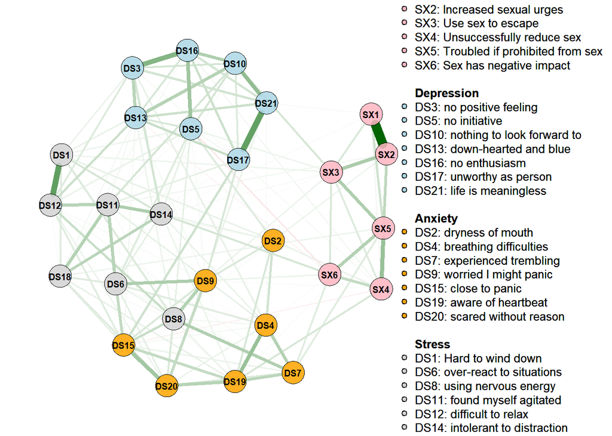

```r
qgraph(male_hetero_network, groups = groups1, nodeNames = Names, color = c("lightpink",
    "lightblue", "orange", "lightgrey"), layout = "spring", minimum = 0, cut = 0,
    curveAll = F, curveDefault = 0.5, label.color = "black", label.prop = 1, label.scale = T,
    label.scale.equal = T, legend.cex = 0.4, font = 2, vsize = 4, posCol = "dark green",
    borders = T, border.color = "black", border.width = 0.2, vTrans = 220, usePCH = F,
    node.resolution = 150)  # ,filetype='tiff',filename='male_hetero_network')
```

#Estimate and plot female_hetero network

```r
female_hetero_network <- as_tibble(getWmat(network_female_hetero <- estimateNetwork(Female_hetero,
    default = "EBICglasso")))

network_female_hetero
```

```
##
## === Estimated network ===
## Number of nodes: 27
## Number of non-zero edges: 139 / 351
## Mean weight: 0.03470967
## Network stored in x$graph
##
## Default set used: EBICglasso
##
## Use plot(x) to plot estimated network
## Use bootnet(x) to bootstrap edge weights and centrality indices
##
## Relevant references:
##
##      Friedman, J. H., Hastie, T., & Tibshirani, R. (2008). Sparse inverse covariance estimation with the graphical lasso. Biostatistics, 9 (3), 432-441.
##  Foygel, R., & Drton, M. (2010). Extended Bayesian information criteria for Gaussian graphical models.
##  Friedman, J. H., Hastie, T., & Tibshirani, R. (2014). glasso: Graphical lasso estimation of gaussian graphical models. Retrieved from https://CRAN.R-project.org/package=glasso
##  Epskamp, S., Cramer, A., Waldorp, L., Schmittmann, V. D., & Borsboom, D. (2012). qgraph: Network visualizations of relationships in psychometric data. Journal of Statistical Software, 48 (1), 1-18.
##  Epskamp, S., Borsboom, D., & Fried, E. I. (2016). Estimating psychological networks and their accuracy: a tutorial paper. arXiv preprint, arXiv:1604.08462.
```

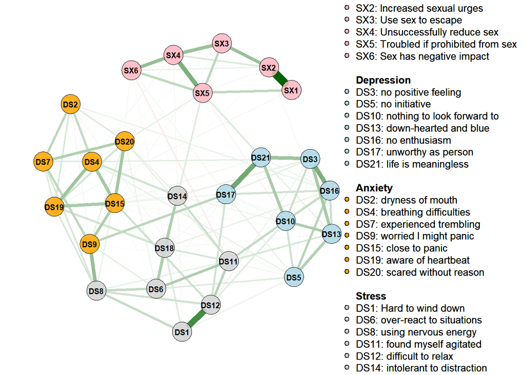

```r
qgraph(female_hetero_network, groups = groups1, nodeNames = Names, color = c("lightpink",
    "lightblue", "orange", "lightgrey"), layout = "spring", minimum = 0, cut = 0,
    curveAll = F, curveDefault = 0.5, label.color = "black", label.prop = 1, label.scale = T,
    label.scale.equal = T, legend.cex = 0.4, font = 2, vsize = 4, posCol = "dark green",
    borders = T, border.color = "black", border.width = 0.2, vTrans = 220, usePCH = F,
    node.resolution = 150)  # ,filetype='tiff',filename='female_hetero_network')
```

#Estimate and plot LGBTQ network

```r
LGBTQ_network <- as_tibble(getWmat(network_LGBTQ <- estimateNetwork(LGBTQ, default = "EBICglasso")))

network_LGBTQ
```

```
##
## === Estimated network ===
## Number of nodes: 27
## Number of non-zero edges: 146 / 351
## Mean weight: 0.03466223
## Network stored in x$graph
##
## Default set used: EBICglasso
##
## Use plot(x) to plot estimated network
## Use bootnet(x) to bootstrap edge weights and centrality indices
##
## Relevant references:
##
##      Friedman, J. H., Hastie, T., & Tibshirani, R. (2008). Sparse inverse covariance estimation with the graphical lasso. Biostatistics, 9 (3), 432-441.
##  Foygel, R., & Drton, M. (2010). Extended Bayesian information criteria for Gaussian graphical models.
##  Friedman, J. H., Hastie, T., & Tibshirani, R. (2014). glasso: Graphical lasso estimation of gaussian graphical models. Retrieved from https://CRAN.R-project.org/package=glasso
##  Epskamp, S., Cramer, A., Waldorp, L., Schmittmann, V. D., & Borsboom, D. (2012). qgraph: Network visualizations of relationships in psychometric data. Journal of Statistical Software, 48 (1), 1-18.
##  Epskamp, S., Borsboom, D., & Fried, E. I. (2016). Estimating psychological networks and their accuracy: a tutorial paper. arXiv preprint, arXiv:1604.08462.
```

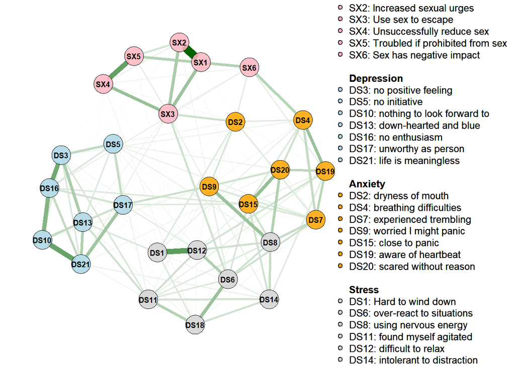

```r
qgraph(LGBTQ_network, groups = groups1, nodeNames = Names, color = c("lightpink",
    "lightblue", "orange", "lightgrey"), layout = "spring", minimum = 0, cut = 0,
    curveAll = F, curveDefault = 0.5, label.color = "black", label.prop = 1, label.scale = T,
    label.scale.equal = T, legend.cex = 0.4, font = 2, vsize = 4, posCol = "dark green",
    borders = T, border.color = "black", border.width = 0.2, vTrans = 220, usePCH = F,
    node.resolution = 150)  # ,filetype='tiff',filename='LGBTQnetwork')
```

#Network Comparison Test Male to Female

```r
set.seed(123)
Comparison_M_F <- NCT(network_males_hetero, network_female_hetero, gamma, it = 100,
    binary.data = FALSE, paired = FALSE, weighted = TRUE, AND = TRUE, test.edges = TRUE,
    edges = "ALL", progressbar = FALSE, test.centrality = TRUE)

Comparison_M_F
```

```
##
##  NETWORK INVARIANCE TEST
##  Test statistic M:
##  0.1840963
##  p-value 0.7326733
##
##  GLOBAL STRENGTH INVARIANCE TEST
##  Global strength per group:  12.72021 12.52557
##  Test statistic S:  0.1946358
##  p-value 0.5148515
##
##  EDGE INVARIANCE TEST
##     Var1 Var2    p-value Test statistic E
## 28   SX1  SX2 0.71287129       0.02097252
## 55   SX1  SX3 0.37623762       0.05461678
```

[output cut: 379 more lines]

#Network Comparison Test Male to LGBTQ

```r
set.seed(123)
Comparison_M_L <- NCT(network_males_hetero, network_LGBTQ, gamma, it = 100, binary.data = FALSE,
    paired = FALSE, weighted = TRUE, AND = TRUE, test.edges = TRUE, edges = "ALL",
    progressbar = FALSE, test.centrality = TRUE)

Comparison_M_L
```

```
##
##  NETWORK INVARIANCE TEST
##  Test statistic M:
##  0.1799742
##  p-value 0.7425743
##
##  GLOBAL STRENGTH INVARIANCE TEST
##  Global strength per group:  12.72021 12.36947
##  Test statistic S:  0.3507408
##  p-value 0.2871287
##
##  EDGE INVARIANCE TEST
##     Var1 Var2    p-value Test statistic E
## 28   SX1  SX2 0.96039604       0.00292782
## 55   SX1  SX3 0.04950495       0.14199252
```

[output cut: 379 more lines]

#Network Comparison Test Female to LGBTQ

```r
set.seed(123)
Comparison_F_L <- NCT(network_female_hetero, network_LGBTQ, gamma, it = 100, binary.data = FALSE,
    paired = FALSE, weighted = TRUE, AND = TRUE, test.edges = TRUE, edges = "ALL",
    progressbar = FALSE, test.centrality = TRUE)

Comparison_F_L
```

```
##
##  NETWORK INVARIANCE TEST
##  Test statistic M:
##  0.2149298
##  p-value 0.6039604
##
##  GLOBAL STRENGTH INVARIANCE TEST
##  Global strength per group:  12.52557 12.36947
##  Test statistic S:  0.156105
##  p-value 0.7326733
##
##  EDGE INVARIANCE TEST
##     Var1 Var2    p-value Test statistic E
## 28   SX1  SX2 0.73267327       0.01804470
## 55   SX1  SX3 0.03960396       0.19660930
```

[output cut: 379 more lines]

#Plot centrality indices

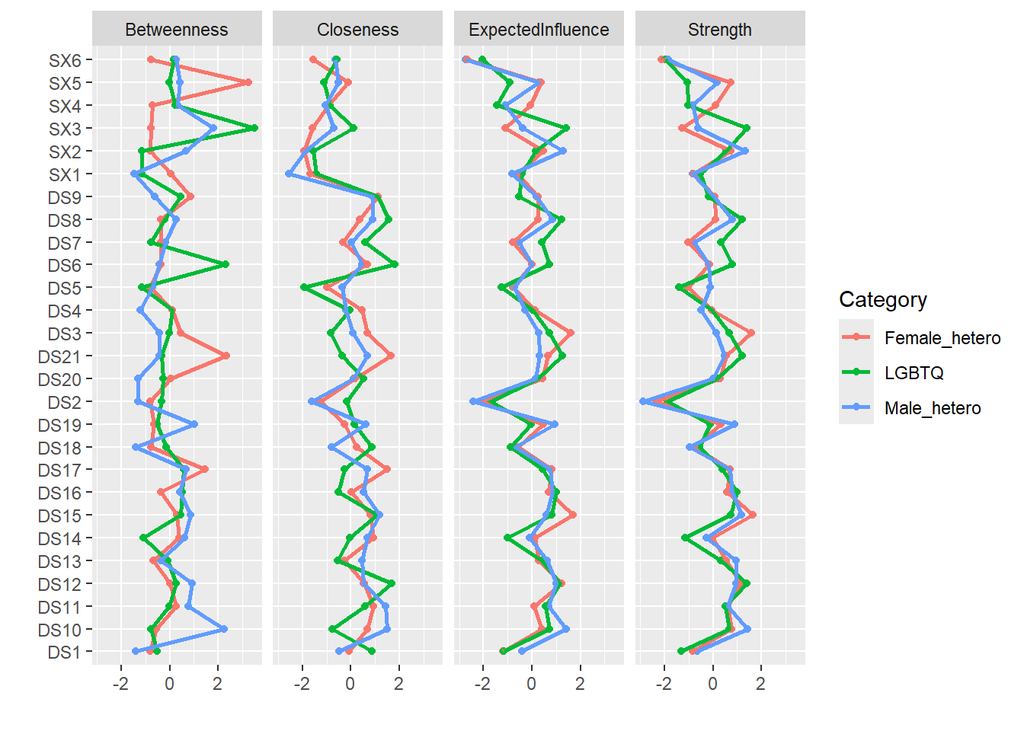

```r
cent_males <- as_tibble(centralityTable(network_males_hetero))

cent_females <- as_tibble(centralityTable(network_female_hetero))

cent_LGBTQ <- as_tibble(centralityTable(network_LGBTQ))

## Plot centrality indices
cent_males$Category <- "Male_hetero"
cent_females$Category <- "Female_hetero"
cent_LGBTQ$Category <- "LGBTQ"
many_BDF <- list(cent_females, cent_males, cent_LGBTQ)
Gender <- as_tibble(Reduce(function(...) merge(..., all = T), many_BDF))

write.csv(Gender, file = "Gender_centrality_index.csv")

Gender <- read.csv("Gender_centrality_index.csv")

Gender %>%
    ggplot(aes(x = node, y = value, color = Category, group = Category)) + geom_point() +
    geom_line(size = 1) + coord_flip() + facet_wrap(~measure, nrow = 1) + labs(x = "",
    y = "")
```

```r
## Write excel files with correlation matrices for males and females
cor_mat_males <- as_tibble(getWmat(network_males_hetero))
write_csv(cor_mat_males, "Correlation matrix male_hetero.csv")
cor_mat_females <- as_tibble(getWmat(network_female_hetero))
write_csv(cor_mat_females, "Correlation matrix female_hetero.csv")
cor_mat_LGBTQ <- as_tibble(getWmat(network_LGBTQ))
write_csv(cor_mat_LGBTQ, "Correlation matrix LGBTQ.csv")
```

#Plot Bridge symptoms

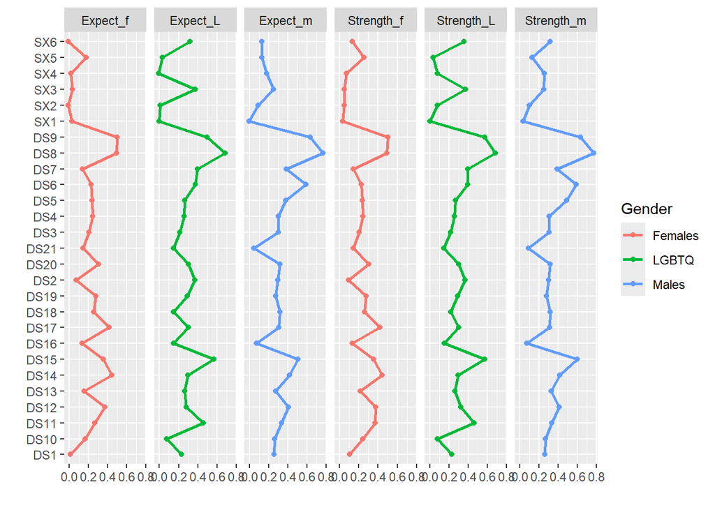

```r
## Prepping male_hetero data frame
graph_males <- qgraph::EBICglasso(cor(Male_hetero), n=dim(Male_hetero)[1])
 b_males <- bridge(graph_males, communities = groups1)
 Strength_m <-  b_males$`Bridge Strength`

 Expect_m <-  b_males$`Bridge Expected Influence (1-step)`
Bsymptoms_m <- Male_hetero%>%
  pivot_longer(cols = c(1:27), names_to = "symptoms", values_to = "n")%>%
  select(symptoms) %>%
  slice_head(n=27)

 symptoms_m <- tibble::tibble(
  Bsymptoms_m,
  Strength_m,

  Expect_m
) %>%
  mutate(
    `Bridge strength` = (Strength_m - mean(Strength_m)) / sd(Strength_m),

    `Bridge expect inf` = (Expect_m - mean(Expect_m)) / sd(Expect_m)
  ) %>%
  tidyr::pivot_longer(
    cols = c(Strength_m,  Expect_m),
    names_to = "Bcent",
    values_to = "n"
  )

## Prepping female_hetero data frame
graph_females <- qgraph::EBICglasso(cor(Female_hetero), n=dim(Female_hetero)[1])
b_females <- bridge(graph_females, communities = groups1)
Strength_f <- b_females$`Bridge Strength`

Expect_f <- b_females$`Bridge Expected Influence (1-step)`
Bsymptoms_f <- Female_hetero%>%
  pivot_longer(cols = c(1:27), names_to = "symptoms", values_to = "n")%>%
  select(symptoms) %>%
  slice_head(n=27)


symptoms_f <- tibble::tibble(
  Bsymptoms_f,
  Strength_f,

  Expect_f
) %>%
  mutate(
    `Bridge strength` = (Strength_f - mean(Strength_f)) / sd(Strength_f),

    `Bridge expect inf` = (Expect_f - mean(Expect_f)) / sd(Expect_f)
  ) %>%
  tidyr::pivot_longer(
    cols = c(Strength_f, Expect_f),
    names_to = "Bcent",
    values_to = "n"
  )

## Prepping LGBTQ data frame
graph_LGBTQ <- qgraph::EBICglasso(cor(LGBTQ), n=dim(LGBTQ)[1])
b_LGBTQ <- bridge(graph_LGBTQ, communities = groups1)
Strength_L <- b_LGBTQ$`Bridge Strength`

Expect_L <- b_LGBTQ$`Bridge Expected Influence (1-step)`
Bsymptoms_L <- LGBTQ%>%
  pivot_longer(cols = c(1:27), names_to = "symptoms", values_to = "n")%>%
  select(symptoms) %>%
  slice_head(n=27)

symptoms_L <- tibble::tibble(
  Bsymptoms_L,
  Strength_L,

  Expect_L
) %>%
  mutate(
    `Bridge strength` = (Strength_L - mean(Strength_L)) / sd(Strength_L),

    `Bridge expect inf` = (Expect_L - mean(Expect_L)) / sd(Expect_L)
  ) %>%
  tidyr::pivot_longer(
    cols = c(Strength_L,  Expect_L),
    names_to = "Bcent",
    values_to = "n"
  )


## Plot centrality indices
symptoms_m$Gender <- 'Males'
symptoms_f$Gender <- 'Females'
symptoms_L$Gender <- 'LGBTQ'
Brian_many_SDF_bridge <- list(symptoms_m,symptoms_f, symptoms_L)
B_bridge_Gender <- as_tibble(Reduce(function(...) merge(..., all=T), Brian_many_SDF_bridge))

write.csv(B_bridge_Gender, file = "Bridge Centrality.csv")

B_bridge_Gender <- read.csv("Bridge Centrality.csv")

B_bridge_Gender %>%
  ggplot(aes(x = symptoms,  y = n, color = Gender, group = Gender)) +
  geom_point() +
  geom_line(size=1.0) +
  coord_flip() +
  facet_wrap(~Bcent, nrow = 1)+
  labs(x = "", y = "")
```

#Hill climbing algorithm is used to learn/determine the initial structure of the Bayesian network

```
##
##   Bayesian network learned via Score-based methods
##
##   model:
##    [DS1][DS12|DS1][DS8|DS1:DS12][DS15|DS8:DS12][DS6|DS8:DS12:DS15]
##    [DS9|DS6:DS8:DS15][DS11|DS6:DS12:DS15][SX1|DS8:DS11][DS17|DS9:DS11:DS12:DS15]
##    [DS20|DS6:DS8:DS9:DS15][DS7|DS8:DS15:DS20][DS4|DS6:DS7:DS11:DS20]
##    [DS21|DS4:DS12:DS17][DS10|DS1:DS11:DS17:DS21][DS16|DS10:DS12:DS17:DS21]
##    [DS3|DS4:DS10:DS12:DS16:DS21][DS5|DS1:DS6:DS8:DS10:DS16][SX2|SX1:DS5:DS6]
##    [DS13|DS3:DS5:DS10:DS12:DS15:DS17:DS21][SX3|SX1:SX2:DS9:DS10]
##    [SX5|SX1:SX2:SX3:DS7][SX6|SX3:SX5:DS5:DS7:DS9][SX4|SX2:SX5:SX6:DS3]
##    [DS19|SX4:DS4:DS7:DS15:DS20][DS2|SX2:DS4:DS5:DS9:DS19]
##    [DS14|SX6:DS1:DS3:DS6:DS11:DS19][DS18|DS1:DS11:DS14:DS15:DS20]
##   nodes:                                 27
##   arcs:                                  100
##     undirected arcs:                     0
##     directed arcs:                       100
##   average markov blanket size:           13.04
##   average neighbourhood size:            7.41
##   average branching factor:              3.70
##
##   learning algorithm:                    Hill-Climbing
##   score:                                 BIC (Gauss.)
##   penalization coefficient:              3.135494
##   tests used in the learning procedure:  3055
##   optimized:                             TRUE
```

#Hill climbing algorithm is used to learn/determine the initial structure of the Bayesian network

```
##
##   Bayesian network learned via Score-based methods
##
##   model:
##    [SX1][DS2][SX2|SX1][SX3|SX2][SX4|SX2:SX3][DS4|SX3:DS2][DS15|DS4]
##    [DS20|DS2:DS15][SX5|SX1:SX4:DS20][DS7|DS2:DS4:DS20][SX6|SX4:SX5]
##    [DS9|DS7:DS15][DS19|DS4:DS7:DS15][DS8|DS9:DS19:DS20][DS1|DS8:DS15]
##    [DS12|DS1:DS8:DS15][DS3|SX5:DS4:DS7:DS12][DS10|SX5:DS3:DS12]
##    [DS11|DS8:DS10:DS12:DS19][DS16|DS2:DS3:DS10][DS21|SX5:DS3:DS10:DS15]
##    [DS13|DS3:DS10:DS11:DS16][DS14|SX5:DS4:DS11:DS16][DS17|DS9:DS12:DS16:DS21]
##    [DS5|DS1:DS13:DS16][DS6|DS8:DS11:DS14][DS18|DS1:DS6:DS14:DS16:DS19]
##   nodes:                                 27
##   arcs:                                  71
##     undirected arcs:                     0
##     directed arcs:                       71
##   average markov blanket size:           8.67
##   average neighbourhood size:            5.26
##   average branching factor:              2.63
##
##   learning algorithm:                    Hill-Climbing
##   score:                                 BIC (Gauss.)
##   penalization coefficient:              2.675929
##   tests used in the learning procedure:  2249
##   optimized:                             TRUE
```

#Hill climbing algorithm is used to learn/determine the initial structure of the Bayesian network

```
##
##   Bayesian network learned via Score-based methods
##
##   model:
##    [DS1][DS12|DS1][DS6|DS12][DS8|DS6:DS12][DS18|DS1:DS6][DS11|DS8:DS12:DS18]
##    [DS10|DS11][DS16|DS10:DS12][DS15|DS6:DS8:DS16][DS20|DS8:DS15]
##    [DS4|DS1:DS15:DS20][DS21|DS10:DS16:DS20][SX3|DS6:DS21]
##    [DS13|DS1:DS10:DS11:DS21][DS17|DS6:DS12:DS16:DS21][SX1|SX3][SX4|SX3:DS18]
##    [DS3|DS1:DS13:DS16][DS9|DS4:DS8:DS17][SX2|SX1:SX3][DS2|SX3:DS4:DS9]
##    [DS5|DS3:DS8:DS17][SX5|SX2:SX4:DS18][SX6|SX5:DS4][DS19|SX6:DS4:DS12:DS20]
##    [DS7|DS4:DS6:DS8:DS19][DS14|DS8:DS18:DS19:DS21]
##   nodes:                                 27
##   arcs:                                  67
##     undirected arcs:                     0
##     directed arcs:                       67
##   average markov blanket size:           7.93
##   average neighbourhood size:            4.96
##   average branching factor:              2.48
##
##   learning algorithm:                    Hill-Climbing
##   score:                                 BIC (Gauss.)
##   penalization coefficient:              2.633929
##   tests used in the learning procedure:  2769
##   optimized:                             TRUE
```

#Networks are bootstrapped with 200 iterations to obtain a stable network. Bootstrapped networks can then be saved. Results exported to csv for further analysis in excel

```r
# BSThcMale <- boot.strength(bn_male_data, R = 200, algorithm = 'hc', debug =
# TRUE, cpdag = TRUE)

# saveRDS(BSThcMale, file = 'BSThcMale.RDS')
BSThcMale <- readRDS("BSThcMale.RDS")

# write.csv(BSThcMale, file = 'BSThcMale.csv')


# BSThcFemale <- boot.strength(bn_female_data, R = 200, algorithm = 'hc', debug
# = TRUE, cpdag = TRUE)

# saveRDS(BSThcFemale, file = 'BSThcFemale.RDS')
BSThcFemale <- readRDS("BSThcFemale.RDS")

# write.csv(BSThcFemale, file = 'BSThcFemale.csv')


# BSThcLGBTQ <- boot.strength(bn_LGBTQ_data, R = 200, algorithm = 'hc', debug =
# TRUE, cpdag = TRUE)

# saveRDS(BSThcLGBTQ, file = 'BSThcLGBTQ.RDS')
BSThcLGBTQ <- readRDS("BSThcLGBTQ.RDS")

# write.csv(BSThcLGBTQ, file = 'BSThcLGBTQ.csv')
```

#Network is averaged using Scutari’s (2010) method of discerning edge significance

```r
avgnet_scutari_m <- averaged.network(BSThcMale)
avgnet_scutari_m
```

```
##
##   Random/Generated Bayesian network
##
##   model:
##     [partially directed graph]
##   nodes:                                 27
##   arcs:                                  77
##     undirected arcs:                     1
##     directed arcs:                       76
##   average markov blanket size:           9.41
##   average neighbourhood size:            5.70
##   average branching factor:              2.81
##
##   generation algorithm:                  Model Averaging
##   significance threshold:                0.5
```

#Network is averaged using Scutari’s (2010) method of discerning edge significance

```r
avgnet_scutari_f <- averaged.network(BSThcFemale)
avgnet_scutari_f
```

```
##
##   Random/Generated Bayesian network
##
##   model:
##    [SX4][DS3][SX2|SX4][DS16|DS3][DS21|DS3][SX1|SX2][SX3|SX2:SX4][DS17|DS16:DS21]
##    [SX5|SX1:SX3:SX4][DS12|DS17][SX6|SX4:SX5][DS10|SX5:DS3:DS16:DS21][DS15|DS12]
##    [DS4|DS3:DS15][DS9|DS15:DS17][DS13|DS3:DS10:DS16][DS20|DS15]
##    [DS5|DS10:DS13:DS16][DS8|DS9:DS12][DS11|DS10:DS12:DS13][DS1|DS8:DS12]
##    [DS7|DS4:DS8:DS9:DS20][DS14|DS4:DS11][DS2|DS4:DS7][DS6|DS8:DS11:DS14]
##    [DS19|DS7:DS15][DS18|DS6:DS14:DS19]
##   nodes:                                 27
##   arcs:                                  53
##     undirected arcs:                     0
##     directed arcs:                       53
##   average markov blanket size:           5.56
##   average neighbourhood size:            3.93
##   average branching factor:              1.96
##
##   generation algorithm:                  Model Averaging
##   significance threshold:                0.49
```

#Network is averaged using Scutari’s (2010) method of discerning edge significance

```r
avgnet_scutari_L <- averaged.network(BSThcLGBTQ)
avgnet_scutari_L
```

```
##
##   Random/Generated Bayesian network
##
##   model:
##    [SX2][DS8][DS10][SX1|SX2][DS12|DS8][DS20|DS8][DS21|DS10][DS6|DS8:DS12]
##    [DS13|DS10:DS21][DS16|DS10:DS21][DS17|DS12:DS21][SX3|SX1:SX2:DS6]
##    [DS1|DS12:DS13][DS3|DS13:DS16][DS7|DS6:DS8][DS9|DS8:DS10:DS17]
##    [DS11|DS6:DS8:DS12:DS13][DS15|DS6:DS8:DS16:DS20][DS2|SX3:DS9]
##    [DS5|DS3:DS8:DS17][DS18|DS1:DS6:DS11][DS19|DS7:DS12:DS20][SX4|SX3:DS18]
##    [DS4|DS7:DS19:DS20][DS14|DS8:DS18][SX5|SX2:SX4][SX6|SX5:DS4]
##   nodes:                                 27
##   arcs:                                  54
##     undirected arcs:                     0
##     directed arcs:                       54
##   average markov blanket size:           5.93
##   average neighbourhood size:            4.00
##   average branching factor:              2.00
##
##   generation algorithm:                  Model Averaging
##   significance threshold:                0.5
```

#Plot heterosexual male DAG

```r
bayesianNetwork.boot.strength = BSThcMale
#boot.strength(Males, R = 200, algorithm = "hc")
##boot.strength command not used as we have already conducted hill climbing algorithm and conducted bootstrapping separately. Alternatively, boot.strength command can be used to obtain the network and conduct bootstrapping. Other algorithms can also be used to obtain the network. By performing these tasks separately, we are able to save progress along the way and avoid rerunning these processes.

avg.bayesianNetwork = averaged.network(bayesianNetwork.boot.strength, threshold = 0.50)

#clusters.legend.title = "<b>Legend</b> <br> Variable Categories"

strength.viewer(
    avg.bayesianNetwork,
    bayesianNetwork.boot.strength,
    bayesianNetwork.background = "white",
    bayesianNetwork.arc.strength.threshold.expression = c("@threshold > 0 & @threshold < 0.85",
                                "@threshold >= 0.85 & @threshold <= 0.90",
                                "@threshold > 0.90 & @threshold <= 1"),

    bayesianNetwork.arc.strength.threshold.expression.color  = c("grey", "light blue", "blue"),
    bayesianNetwork.arc.strength.threshold.alternative.color =  "white",

    bayesianNetwork.arc.strength.tooltip = T,
    #bayesianNetwork.enabled.interactive.mode = TRUE, ##Enables an interactive viewer module for data visualisation

    bayesianNetwork.edge.scale.min = .1,
    bayesianNetwork.edge.scale.max = 5,

    bayesianNetwork.arc.strength.label = F,
    bayesianNetwork.edge.scale.label.min = 12,
    bayesianNetwork.edge.scale.label.max = 12,
    node.shape = "circle",
    node.size = 72,
    node.colors = list(background = "#97c2fc",
                     border = "black",
                     highlight = list(background = "#e91eba",
                                      border = "#2b7ce9")),
node.label.prefix = "",
  node.font = list(color = "black", face="source sans pro black"),

#clusters.legend.title = list(text = clusters.legend.title,
#                                    style = "font-size:12px;
#                                             font-family:Arial;
#                                             color:black;
#                                             text-align:center;"),
clusters.legend.options = list(
  list(label = "BYSAS",
       shape = "icon",
       icon = list(code = "f111", size = 20, color = "pink")   ),
    list(label = "Depression",
       shape = "icon",
       icon = list(code = "f111", size = 20, color = "lightblue")   ) ,
    list(label = "Anxiety",
       shape = "icon",
       icon = list(code = "f111", size = 20, color = "orange")   ) ,
    list(label = "Stress",
       shape = "icon",
       icon = list(code = "f111", size = 20, color = "grey")   )
  ),

clusters = list(
  list(label = "BYSAS",
      shape = "icon",
       icon = list(code = "f10c", size = 72, color = "pink"),
       nodes = list("SX1", "SX2", "SX3", "SX4", "SX5", "SX6")),
  list(label = "Depression",
      shape = "icon",
       icon = list(code = "f10c", size = 72, color = "lightblue"),
       nodes = list("DS3", "DS5", "DS10", "DS13", "DS16", "DS17", "DS21")),
  list(label = "Anxiety",
      shape = "icon",
       icon = list(code = "f10c", size = 72, color = "orange"),
       nodes = list("DS2", "DS4", "DS7", "DS9", "DS15", "DS19", "DS20")),
  list(label = "Stress",
      shape = "icon",
       icon = list(code = "f10c", size = 72, color = "grey"),
       nodes = list("DS1", "DS6", "DS8", "DS11", "DS12", "DS14", "DS18"))

  ),



    bayesianNetwork.width = "100%",
    bayesianNetwork.height = "600px",
    bayesianNetwork.layout = "layout_components")
```

[interactive chart not shown]

```r
##Alternate layout options and arguments available at http://robsonfernandes.net/bnviewer/#documentation
```

#Plot heterosexual female DAG

```r
bayesianNetwork.boot.strength = BSThcFemale
#boot.strength(Males, R = 200, algorithm = "hc")
##boot.strength command not used as we have already conducted hill climbing algorithm and conducted bootstrapping separately. Alternatively, boot.strength command can be used to obtain the network and conduct bootstrapping. Other algorithms can also be used to obtain the network. By performing these tasks separately, we are able to save progress along the way and avoid rerunning these processes.

avg.bayesianNetwork = averaged.network(bayesianNetwork.boot.strength, threshold = 0.49)



strength.viewer(
    avg.bayesianNetwork,
    bayesianNetwork.boot.strength,
    bayesianNetwork.background = "white",
    bayesianNetwork.arc.strength.threshold.expression = c("@threshold > 0 & @threshold < 0.85",
                                "@threshold >= 0.85 & @threshold <= 0.90",
                                "@threshold > 0.90 & @threshold <= 1"),

    bayesianNetwork.arc.strength.threshold.expression.color  = c("grey", "light blue", "blue"),
    bayesianNetwork.arc.strength.threshold.alternative.color =  "white",

    bayesianNetwork.arc.strength.tooltip = T,
    #bayesianNetwork.enabled.interactive.mode = TRUE, ##Enables an interactive viewer module for data visualisation

    bayesianNetwork.edge.scale.min = .1,
    bayesianNetwork.edge.scale.max = 5,

    bayesianNetwork.arc.strength.label = F,
    bayesianNetwork.edge.scale.label.min = 12,
    bayesianNetwork.edge.scale.label.max = 12,
    node.shape = "circle",
    node.size = 72,
    node.colors = list(background = "#97c2fc",
                     border = "black",
                     highlight = list(background = "#e91eba",
                                      border = "#2b7ce9")),
node.label.prefix = "",
  node.font = list(color = "black", face="source sans pro black"),

#clusters.legend.title = list(text = clusters.legend.title,
#                                    style = "font-size:18px;
#                                             font-family:Arial;
#                                             color:black;
#                                             text-align:center;"),
clusters.legend.options = list(
  list(label = "BYSAS",
       shape = "icon",
       icon = list(code = "f111", size = 20, color = "pink")   ),
    list(label = "Depression",
       shape = "icon",
       icon = list(code = "f111", size = 20, color = "lightblue")   ) ,
    list(label = "Anxiety",
       shape = "icon",
       icon = list(code = "f111", size = 20, color = "orange")   ) ,
    list(label = "Stress",
       shape = "icon",
       icon = list(code = "f111", size = 20, color = "grey")   )
  ),

clusters = list(
  list(label = "BYSAS",
      shape = "icon",
       icon = list(code = "f10c", size = 72, color = "pink"),
       nodes = list("SX1", "SX2", "SX3", "SX4", "SX5", "SX6")),
  list(label = "Depression",
      shape = "icon",
       icon = list(code = "f10c", size = 72, color = "lightblue"),
       nodes = list("DS3", "DS5", "DS10", "DS13", "DS16", "DS17", "DS21")),
  list(label = "Anxiety",
      shape = "icon",
       icon = list(code = "f10c", size = 72, color = "orange"),
       nodes = list("DS2", "DS4", "DS7", "DS9", "DS15", "DS19", "DS20")),
  list(label = "Stress",
      shape = "icon",
       icon = list(code = "f10c", size = 72, color = "grey"),
       nodes = list("DS1", "DS6", "DS8", "DS11", "DS12", "DS14", "DS18"))

  ),



    bayesianNetwork.width = "100%",
    bayesianNetwork.height = "600px",
    bayesianNetwork.layout = "layout_components")
```

[interactive chart not shown]

```r
##Alternate layout options and arguments available at http://robsonfernandes.net/bnviewer/#documentation
```

#Plot LGBTQ DAG

```r
bayesianNetwork.boot.strength = BSThcLGBTQ
#boot.strength(Males, R = 200, algorithm = "hc")
##boot.strength command not used as we have already conducted hill climbing algorithm and conducted bootstrapping separately. Alternatively, boot.strength command can be used to obtain the network and conduct bootstrapping. Other algorithms can also be used to obtain the network. By performing these tasks separately, we are able to save progress along the way and avoid rerunning these processes.

avg.bayesianNetwork = averaged.network(bayesianNetwork.boot.strength, threshold = 0.50)



strength.viewer(
    avg.bayesianNetwork,
    bayesianNetwork.boot.strength,
    bayesianNetwork.background = "white",
    bayesianNetwork.arc.strength.threshold.expression = c("@threshold > 0 & @threshold < 0.85",
                                "@threshold >= 0.85 & @threshold <= 0.90",
                                "@threshold > 0.90 & @threshold <= 1"),

    bayesianNetwork.arc.strength.threshold.expression.color  = c("grey", "light blue", "blue"),
    bayesianNetwork.arc.strength.threshold.alternative.color =  "white",

    bayesianNetwork.arc.strength.tooltip = T,
    #bayesianNetwork.enabled.interactive.mode = TRUE, ##Enables an interactive viewer module for data visualisation

    bayesianNetwork.edge.scale.min = .1,
    bayesianNetwork.edge.scale.max = 5,

    bayesianNetwork.arc.strength.label = F,
    bayesianNetwork.edge.scale.label.min = 12,
    bayesianNetwork.edge.scale.label.max = 12,
    node.shape = "circle",
    node.size = 72,
    node.colors = list(background = "#97c2fc",
                     border = "black",
                     highlight = list(background = "#e91eba",
                                      border = "#2b7ce9")),
node.label.prefix = "",
  node.font = list(color = "black", face="source sans pro black"),

#clusters.legend.title = list(text = clusters.legend.title,
#                                    style = "font-size:18px;
#                                             font-family:Arial;
#                                             color:black;
#                                             text-align:center;"),
clusters.legend.options = list(
  list(label = "BYSAS",
       shape = "icon",
       icon = list(code = "f111", size = 20, color = "pink")   ),
    list(label = "Depression",
       shape = "icon",
       icon = list(code = "f111", size = 20, color = "lightblue")   ) ,
    list(label = "Anxiety",
       shape = "icon",
       icon = list(code = "f111", size = 20, color = "orange")   ) ,
    list(label = "Stress",
       shape = "icon",
       icon = list(code = "f111", size = 20, color = "grey")   )
  ),

clusters = list(
  list(label = "BYSAS",
      shape = "icon",
       icon = list(code = "f10c", size = 72, color = "pink"),
       nodes = list("SX1", "SX2", "SX3", "SX4", "SX5", "SX6")),
  list(label = "Depression",
      shape = "icon",
       icon = list(code = "f10c", size = 72, color = "lightblue"),
       nodes = list("DS3", "DS5", "DS10", "DS13", "DS16", "DS17", "DS21")),
  list(label = "Anxiety",
      shape = "icon",
       icon = list(code = "f10c", size = 72, color = "orange"),
       nodes = list("DS2", "DS4", "DS7", "DS9", "DS15", "DS19", "DS20")),
  list(label = "Stress",
      shape = "icon",
       icon = list(code = "f10c", size = 72, color = "grey"),
       nodes = list("DS1", "DS6", "DS8", "DS11", "DS12", "DS14", "DS18"))

  ),



    bayesianNetwork.width = "100%",
    bayesianNetwork.height = "600px",
    bayesianNetwork.layout = "layout_components")
```

[interactive chart not shown]

```r
##Alternate layout options and arguments available at http://robsonfernandes.net/bnviewer/#documentation
```